# psychencode_figures_cleaned

Packages etc.

```r
library(dplyr)
library(tidyverse)
library(edgeR)
library(markerGeneProfile)
library(matrixStats)
library(cowplot)
library(broom)
library(knitr)
library(ggpubr)
library(biomaRt)
library(ggrepel)
library(patchwork)
library(ggsignif)
library(modelr)
library(ggbeeswarm)
library(lemon)
library(extrafont)
theme_set(theme_classic2())
#Colour palette
cbPalette = c("#56B4E9", "#009E73","#E69F00", "#0072B2", "#D55E00", "#CC79A7","#000000","#F0E442")
```

Loading Data

```r
#Cell type proportions for each data set merged with metadata - ready for modelling
mgp_estimations = read_csv( "/external/rprshnas01/kcni/dkiss/cell_prop_psychiatry/data/psychencode_mgp_estimations.csv")
acc_estimations = read_csv("/external/rprshnas01/kcni/dkiss/cell_prop_psychiatry/data/cmc_acc_mgp_estimations.csv") %>% filter(primaryDiagnosis %in% c("control", "Schizophrenia"))
#Factorize newStudy for aesthetic purposes (this orderl ooks good on graphs)
mgp_estimations = mgp_estimations %>% filter(ageDeath >= 15)
mgp_estimations$newStudy = mgp_estimations$newStudy %>% factor(levels = c("Pitt", "GVEX", "NIMH_HBCC", "LIBD_szControl", "MSSM", "Penn"))
mgp_estimations_long = mgp_estimations %>% pivot_longer(cols = Astrocyte:VLMC, names_to = 'cell_type', values_to = 'rel_prop') %>%
  mutate(cell_class = case_when(
    cell_type %in% c( "PVALB", "SST", "VIP", "LAMP5", "PAX6") ~ "Inhibitory",
    cell_type %in% c("IT", "L4.IT", "L5.ET", "L5.6.IT.Car3", "L5.6.NP", "L6.CT", "L6b") ~ "Excitatory",
    TRUE ~ "Non-Neuronal"
  ))
mgp_estimations_long$cell_type = mgp_estimations_long$cell_type %>% factor(levels = c("PVALB", "SST", "VIP", "LAMP5", "PAX6", "IT", "L4.IT", "L5.ET", "L5.6.IT.Car3", "L5.6.NP", "L6.CT", "L6b", "Astrocyte", "Endothelial", "Microglia", "Oligodendrocyte", "OPC", "Pericyte", "VLMC"))
mgp_estimations_long$cell_class = mgp_estimations_long$cell_class %>% factor(levels = c("Inhibitory", "Excitatory", "Non-Neuronal"))

acc_estimations_long = acc_estimations %>% pivot_longer(cols = Astrocyte:VLMC, names_to = 'cell_type', values_to = 'rel_prop') %>%
  mutate(cell_class = case_when(
    cell_type %in% c("PVALB", "SST", "VIP", "LAMP5", "PAX6") ~ "Inhibitory",
    cell_type %in% c("IT", "L4.IT", "L5.ET", "L5.6.IT.Car3", "L5.6.NP", "L6.CT", "L6b") ~ "Excitatory",
    TRUE ~ "Non-Neuronal"
  ))
acc_estimations_long$cell_type = acc_estimations_long$cell_type %>% factor(levels = c("PVALB", "SST", "VIP", "LAMP5", "PAX6", "IT", "L4.IT", "L5.ET", "L5.6.IT.Car3", "L5.6.NP", "L6.CT", "L6b", "Astrocyte", "Endothelial", "Microglia", "Oligodendrocyte", "OPC", "Pericyte", "VLMC"))
acc_estimations_long$cell_class = acc_estimations_long$cell_class %>% factor(levels = c("Inhibitory", "Excitatory", "Non-Neuronal"))
#Load single cell samples
psychencode_snCTPs = read.csv('/external/rprshnas01/netdata_kcni/stlab/Xiaolin/cell_deconv_data/PsychEncode_label_transferred_snCTP.csv')
snCTP_metadata = read.csv("~/cell_prop_psychiatry/data/psychencode_label_transferred_pseudobulk_metadata.csv")[,-1] %>%
  group_by(ID) %>%
  mutate(total_cells = sum(num_cells)) %>%
  ungroup()
#Add log10 number of cells variable
snCTP_metadata$log10_num_cells = log10(snCTP_metadata$num_cells)
#Add age group variable
snCTP_metadata =  snCTP_metadata %>%
  mutate(age_group = case_when(
    Age < 70 ~ "Under_70", Age >= 70 ~ "Over_70"))
snCTP_metadata$age_group = snCTP_metadata$age_group %>% factor(levels = c("Under_70", "Over_70"))
psychencode_snCTPs = left_join(snCTP_metadata, psychencode_snCTPs)
```

Cohort demographic summary

```r
summary_df = mgp_estimations %>%
  mutate(individualIDSource = factor(newStudy, levels = c("Pitt", "GVEX", "NIMH_HBCC", "LIBD_szControl", "MSSM", "Penn"))) %>%
    group_by(newStudy) %>%
    summarise(
        CohortName = first(newStudy),
        PercentMale = mean(reportedGender == "male", na.rm = TRUE) * 100,
        AvgAge = mean(ageDeath, na.rm = TRUE),
        AgeSD = sd(ageDeath, na.rm = TRUE),
        NumCases = sum(primaryDiagnosis == "Schizophrenia", na.rm = TRUE),
        NumControls = sum(primaryDiagnosis == "control", na.rm = TRUE)
    )
```

Residualize MGPs based on linear model

```r
mgp_estimations_long = mgp_estimations_long %>%
  group_by(cell_type) %>%
  mutate(resid = resid(lm(scale(rel_prop) ~ scale(RIN) + scale(ageDeath) + scale(PMI) +
               reportedGender, data = cur_data()))) %>%
  ungroup()
```

Model rCTPs based on diagnosis and covariates seperately in each cohort

```r
combined_lms = mgp_estimations_long %>%
  group_by(newStudy, cell_type) %>%
  do(tidy(lm(scale(rel_prop) ~ scale(RIN) + scale(ageDeath) + scale(PMI) +
               reportedGender + primaryDiagnosis, data = .))) %>%
  ungroup() %>%
  mutate(padj = p.adjust(p.value, method = 'fdr'),
         term = recode(term,
                       `(Intercept)` = "Intercept",
                       `reportedGendermale` = "gender:Male",
                       `primaryDiagnosisSchizophrenia` = "SCZ",
                       `scale(ageDeath)` = "Age",
                       `scale(PMI)` = "PMI",
                       `scale(RIN)` = "RIN")) %>%
  merge(unique(mgp_estimations_long[c('dataset', 'newStudy')]), by.x = "newStudy") %>%
  merge(unique(mgp_estimations_long[c('cell_class', 'cell_type')]), by.x = "cell_type") %>%
  mutate(newStudy = factor(newStudy, levels = c("Pitt", "GVEX", "NIMH_HBCC", "LIBD_szControl", "MSSM", "Penn")))
```

```r
interaction_lms = mgp_estimations_long %>%
  group_by(newStudy, cell_type) %>%
  do(tidy(lm(scale(rel_prop) ~ scale(RIN) + scale(ageDeath) + scale(PMI) +
               reportedGender + primaryDiagnosis + scale(ageDeath) * primaryDiagnosis, data = .))) %>%
  ungroup() %>%
  mutate(padj = p.adjust(`p.value`, method = 'fdr'),
         term = recode(term,
                       `(Intercept)` = "Intercept",
                       `reportedGendermale` = "gender:Male",
                       `primaryDiagnosisSchizophrenia` = "SCZ",
                       `scale(ageDeath):primaryDiagnosisSchizophrenia` = "Age x Diagnosis",
                       `scale(ageDeath)` = "Age",
                       `scale(PMI)` = "PMI",
                       `scale(RIN)` = "RIN")) %>%
  merge(unique(mgp_estimations_long[c('dataset', 'newStudy')]), by.x = "newStudy") %>%
  merge(unique(mgp_estimations_long[c('cell_class', 'cell_type')]), by.x = "cell_type") %>%
  mutate(newStudy = factor(newStudy, levels = c("Pitt", "GVEX", "NIMH_HBCC", "LIBD_szControl", "MSSM", "Penn")))
```

Interaction mega-analysis w/ all data

```r
mega_lms = mgp_estimations_long %>%
  group_by(cell_type) %>%
  do(tidy(lm(scale(rel_prop) ~ scale(RIN) + scale(ageDeath) + scale(PMI) +
             reportedGender + primaryDiagnosis + newStudy + scale(ageDeath)*primaryDiagnosis, data = .))) %>%
  ungroup() %>%
  mutate(padj = p.adjust(`p.value`, method = 'fdr'),
         term = recode(term,
                       `(Intercept)` = "Intercept",
                       `reportedGendermale` = "gender:Male",
                       `primaryDiagnosisSchizophrenia` = "SCZ",

                       `scale(ageDeath)` = "Age",
                       `scale(ageDeath):primaryDiagnosisSchizophrenia` = "Age x Diagnosis",
                       `scale(PMI)` = "PMI",
                       `newStudyNIMH_HBCC` = "NIMH_HBCC",
                       `newStudyLIBD_szControl` = "LIBD_szControl",
                       `newStudyPitt` = "Pitt",
                       `newStudyMSSM` = "MSSM",
                       `newStudyPenn` = "Penn",
                       `scale(RIN)` = "RIN")) %>%
  merge(unique(mgp_estimations_long[c('cell_class', 'cell_type')]), by.x = "cell_type")
```

Functions to generate age range bins

```r
# Create function to map age to age range
age_to_range = function(age) {
    if(age >= 15 & age < 30) {
    return("15-29")
  } else {
    lower_bound = floor((age - 30) / 10) * 10 + 30
    upper_bound = lower_bound + 9
    return(paste0(lower_bound, "-", upper_bound))
  }
}
# Create function to bin ages to >=70 and <70
classify_ages = function(ages) {
  classifications = ifelse(ages <= 70, "Under 70", "Over 70")
  return(classifications)
}
```

Create age groups from age 20-90 in increments of 10 years. Plot meganalysis beta coeffs against age group.

```r
mgp_estimations_long$age_range = sapply(mgp_estimations_long$ageDeath, age_to_range)

mega_lms_by_age = mgp_estimations_long %>%
  group_by(age_range, cell_type) %>%
  do(tidy(lm(scale(rel_prop) ~ scale(RIN) + scale(PMI) +
             reportedGender + primaryDiagnosis + newStudy, data = .))) %>%
  ungroup() %>%
  mutate(padj = p.adjust(`p.value`, method = 'fdr'),
         term = recode(term,
                       `(Intercept)` = "Intercept",
                       `reportedGendermale` = "gender:Male",
                       `primaryDiagnosisSchizophrenia` = "SCZ",
                       `scale(ageDeath)` = "Age",
                       `scale(PMI)` = "PMI",
                       `newStudyNIMH_HBCC` = "NIMH_HBCC",
                       `newStudyPitt` = "Pitt",
                       `newStudyMSSM` = "MSSM",
                       `newStudyPenn` = "Penn",
                       `scale(RIN)` = "RIN")) %>%
  merge(unique(mgp_estimations_long[c('cell_class', 'cell_type')]), by.x = "cell_type")
```

Bulk RNAseq Meganalysis based on age +/- 70

```r
mgp_estimations_long$age_class <- sapply(mgp_estimations_long$ageDeath, classify_ages) %>% factor(levels = c("Under 70", "Over 70"))
mega_lms_by_age_class = mgp_estimations_long %>%
  group_by(age_class, cell_type) %>%
  do(tidy(lm(scale(rel_prop) ~ scale(RIN) + scale(PMI) +
             reportedGender + newStudy + primaryDiagnosis, data = .))) %>%
  ungroup() %>%
  mutate(padj = p.adjust(`p.value`, method = 'fdr'),
         term = recode(term,
                       `(Intercept)` = "Intercept",
                       `reportedGendermale` = "gender:Male",
                       `primaryDiagnosisSchizophrenia` = "SCZ",
                       `scale(ageDeath)` = "Age",
                       `scale(PMI)` = "PMI",
                       `newStudyNIMH_HBCC` = "NIMH_HBCC",
                       `newStudyPitt` = "Pitt",
                       `newStudyMSSM` = "MSSM",
                       `newStudyPenn` = "Penn",
                       `scale(RIN)` = "RIN")) %>%
  merge(unique(mgp_estimations_long[c('cell_class', 'cell_type')]), by.x = "cell_type")
```

Single Cell Meganalysis with interaction model

```r
snCTPs_long = psychencode_snCTPs %>%
  pivot_longer(cols = Astrocyte:VIP, names_to = 'cell_type', values_to = 'rel_prop',)  %>%
  mutate(cell_class = case_when(
    cell_type %in% c("LAMP5", "PAX6", "PVALB", "SST", "VIP") ~ "Inhibitory",
    cell_type %in% c("IT", "L4.IT", "L5.ET", "L5.6.IT.Car3", "L5.6.NP", "L6.CT", "L6b") ~ "Excitatory",
    TRUE ~ "Non-Neuronal"
  )) %>%
  distinct(cell_type, unique_donor_ID, .keep_all = T)
snCTPs_long$cell_class = snCTPs_long$cell_class %>% factor(levels = c("Inhibitory", "Excitatory", "Non-Neuronal"))
snCTPs_long$cell_type = snCTPs_long$cell_type %>% factor(levels = c("PVALB", "SST", "VIP", "LAMP5", "PAX6", "IT", "L4.IT", "L5.ET", "L5.6.IT.Car3", "L5.6.NP", "L6.CT", "L6b", "Astrocyte", "Endothelial", "Microglia", "Oligodendrocyte", "OPC", "Pericyte", "VLMC"))

sn_mega_lms = snCTPs_long %>% filter(total_cells >= 500) %>%
  group_by(cell_type) %>%
  do(tidy(lm(scale(rel_prop) ~ scale(PMI) + Gender + Institution + Phenotype + scale(Age) * Phenotype, data = .))) %>%
  ungroup() %>%
  mutate(padj = p.adjust(`p.value`, method = 'fdr')) %>%
  # add cell class labels
  mutate(cell_class = case_when(
    cell_type %in% c("LAMP5", "PAX6", "PVALB", "SST", "VIP") ~ "Inhibitory",
    cell_type %in% c("IT", "L4.IT", "L5.ET", "L5.6.IT.Car3", "L5.6.NP", "L6.CT", "L6b") ~ "Excitatory",
    TRUE ~ "Non-Neuronal"
  )) %>%
  mutate(term = recode(term,
                       `(Intercept)` = "Intercept",
                       `reportedGendermale` = "gender:Male",
                       `PhenotypeSZ` = "SCZ",
                       `primaryDiagnosisBipolar Disorder` = "BP",
                       `DxMDD` = "MDD",
                       `scale(Age)` = "Age",
                       `scale(PMI)` = "PMI",
                       `newStudyNIMH_HBCC` = "NIMH_HBCC",
                       `newStudyPitt` = "Pitt",
                       `newStudyMSSM` = "MSSM",
                       `newStudyPenn` = "Penn",
                       `scale(RIN)` = "RIN",
                       `PhenotypeSZ:scale(Age)` = "Interaction"
))
```

Single Cell Meganalysis based on age +/- 70

```r
sn_mega_lms_by_age = snCTPs_long %>% filter(total_cells >= 500) %>%
  group_by(cell_type, age_group) %>%
  do(tidy(lm(scale(rel_prop) ~ scale(PMI) + Gender + Institution + Phenotype, data = .))) %>%
  ungroup() %>%
  mutate(padj = p.adjust(`p.value`, method = 'fdr')) %>%
  mutate(term = recode(term,
                       `(Intercept)` = "Intercept",
                       `reportedGendermale` = "gender:Male",
                       `PhenotypeSZ` = "SCZ",
                       `primaryDiagnosisBipolar Disorder` = "BP",
                       `DxMDD` = "MDD",
                       `scale(ageDeath)` = "Age",
                       `scale(PMI)` = "PMI",
                       `newStudyNIMH_HBCC` = "NIMH_HBCC",
                       `newStudyPitt` = "Pitt",
                       `newStudyMSSM` = "MSSM",
                       `newStudyPenn` = "Penn",
                       `scale(RIN)` = "RIN"))
```

————////FIGURES////————

Figure 1: Illustrating the association between cell prop and diagnosis and cohort specific differences

```r
significant_combined = subset(combined_lms, padj < 0.1 & cell_type %in% c("SST", "PVALB", "VIP") & term == "SCZ")
significant_combined$asterisks <- ifelse(significant_combined$padj <= 0.01, "***",
                                         ifelse(significant_combined$padj <= 0.05, "**", "*"))
significant_combined$vjust <- ifelse(significant_combined$estimate >= 0, -3, 7)

figure_1b = combined_lms %>%
  filter(term == 'SCZ', cell_type %in% c("SST", "PVALB", "VIP")) %>%
  mutate(cell_type = fct_reorder(cell_type, estimate)) %>%
  ggplot(aes(x = newStudy, y = estimate, fill = newStudy)) +
  geom_hline(yintercept = 0) +
  geom_bar(stat = "identity", position = "dodge") +
  geom_errorbar(aes(ymin = estimate - std.error, ymax = estimate + std.error)) +
  ylab('Beta Coefficient') +
  xlab('') +
  scale_fill_manual(values = cbPalette) +
  geom_text(data = significant_combined,
            aes(newStudy, estimate, label = asterisks),
            vjust = significant_combined$vjust) +
  theme(
    axis.text.x = element_blank(),
    axis.text.y = element_text(size = 15),
    axis.title.x = element_text(vjust = 6, size = 15),
    axis.title.y = element_text(size = 16),
    strip.text.x = element_text(size = 14),
    axis.line.x = element_blank(),
    axis.ticks.x = element_blank()) +
  facet_grid(~cell_type, drop = T, scale = "free_x", space = "free") +
  guides(fill = guide_none()) +
  scale_y_continuous(limits = c(-0.9, 0.5))

# Figure 1c: Residualized MGPs vs. Diagnosis
figure_1c <- mgp_estimations_long %>%
  filter(cell_type %in% c("SST", "PVALB", "VIP")) %>%
  ggplot(aes(x = primaryDiagnosis, y = resid)) +
  geom_boxplot(outlier.shape = NA, aes(fill = newStudy, alpha = 0.5), show.legend = F, notch = T) +
  geom_beeswarm(size = 1, alpha = 0.3, aes(colour = newStudy), show.legend = F) +
  ylab('Residualized CTPs') +
  xlab('Diagnosis') +
  scale_x_discrete(labels = c("C", "SCZ")) +
  scale_colour_manual(values = cbPalette) +
  scale_fill_manual(values = cbPalette) +
  theme(
    axis.text.x = element_text(size = 15),
    axis.text.y = element_text(size = 15),
    axis.title.x = element_text(vjust = -2, size = 15),
    axis.title.y = element_text(size = 15),
    strip.text.x = element_text(size = 14),
    strip.text.y = element_text(size = 14)) +
  guides(fill = FALSE) +
  facet_grid(rows = vars(cell_type), cols = vars(newStudy), drop = T, scale = "free", switch = "y", space = "free") +
  geom_signif(comparisons = list(c("control", "Schizophrenia")), map_signif_level = TRUE, , test = wilcox.test) +
  scale_y_continuous(limits = c(-3.5, 3.5))

#Figure 1d - Hisotgram of cohort ages
figure_1d = mgp_estimations %>%
    ggplot(aes(x = ageDeath)) +
    geom_histogram(aes(fill = newStudy)) +
    facet_wrap(~ newStudy, nrow = 6, scales = "free_y") +
    labs(x = "ageDeath", y = "Frequency") +
    scale_fill_manual(values = c("#56B4E9", "#009E73","#E69F00", "#0072B2", "#D55E00", "#CC79A7")) +
  scale_y_continuous(n.breaks = 4) +
  guides(fill = guide_none()) +
  theme(panel.grid = element_blank(),
        strip.background = element_blank(),
        strip.text = element_text(size = rel(0.9), face = "plain"),
    axis.text.x = element_text(size = 13,),
    axis.text.y = element_text(size = 13),
    axis.title.x = element_text( size = 15),
    axis.title.y = element_text(size = 16),
    strip.text.x = element_text(size = 14))

# Combine Figure 1
figure_1_top = (figure_1b | figure_1d) + plot_layout(widths = c(4,2))
figure_1_bottom = figure_1c

figure_1 =  figure_1_top / figure_1_bottom + plot_annotation(tag_levels = 'A') + plot_layout(heights = c(1, 1)) & theme(plot.tag = element_text(size = 25))
figure_1

#Save to plots folder
output_filename <- "~/cell_prop_psychiatry/plots/figure_1.jpg"

# Use ggsave to save the plot as a JPG image
ggsave(output_filename, figure_1, width = 11, height = 13, dpi = 500)
```

[output not shown]

Figure 2: Introducing and presenting an interaction between age and diagnosis w/rt cell proportion.

```r
# Plot interaction beta values from meganalysis
significant_mega = subset(mega_lms, padj <= 0.1 & term == "Age x Diagnosis" & cell_type %in% c("Astrocyte", "IT", "L5.6.NP", "LAMP5", "Microglia", "Oligodendrocyte", "OPC", "Pericyte", "PVALB", "SST", "VIP" ))
significant_mega$asterisks = ifelse(significant_mega$padj <= 0.01, "***",
                                   ifelse(significant_mega$padj <= 0.05, "**", "*"))
significant_mega$vjust = ifelse(significant_mega$estimate >= 0, -3, 3)

# Figure 2a: Results from interaction meganalysis stratified by cell class - plot interaction beta coeff
mega_lms$cell_type = mega_lms$cell_type %>% factor(levels = c("PVALB", "SST", "VIP", "LAMP5", "PAX6", "IT", "L4.IT", "L5.ET", "L5.6.IT.Car3", "L5.6.NP", "L6.CT", "L6b", "Astrocyte", "Endothelial", "Microglia", "Oligodendrocyte", "OPC", "Pericyte", "VLMC"))
figure_2a = mega_lms %>%  filter(cell_type %in% c("Astrocyte", "IT", "L5.6.NP", "LAMP5", "Microglia", "Oligodendrocyte", "OPC","Pericyte", "PVALB", "SST", "VIP" )) %>%
  filter(term %in% 'Age x Diagnosis') %>%
  ggplot(aes(x = cell_type, y = estimate)) +
  geom_hline(yintercept = 0) +
  geom_bar(stat = "identity", position = "dodge") +
  facet_grid(~cell_class, drop = T, scale = "free_x", space = "free") +
  geom_errorbar(aes(ymin = estimate - std.error, ymax = estimate + std.error)) +
  ylab('Interaction Coefficient') +
  xlab('Cell Type') +
  geom_text(data = significant_mega,
            aes(cell_type, estimate, label = asterisks),
            vjust = significant_mega$vjust) +
  theme(
    axis.text.x = element_text(angle = 45, vjust = 1, hjust = 1, size = 12),
    axis.text.y = element_text(size = 15),
    axis.title.x = element_text(vjust = 8, size = 15),
    axis.title.y = element_text(size = 15),
    strip.text.x = element_text(size = 14)) +
  guides(fill = FALSE) +
  scale_y_continuous(limits = c(-0.15, 0.32))

# Figure 2b: Plot beta values from meganalysis in 10-year age bins for SST, PVALB, VIP
significant_mega_age = subset(mega_lms_by_age, padj <= 0.1 & term == "SCZ" & cell_type %in% c("SST", "PVALB", "VIP"))
significant_mega_age$asterisks = ifelse(significant_mega_age$padj <= 0.01, "***",
                                         ifelse(significant_mega_age$padj <= 0.05, "**", "*"))
significant_mega_age$vjust = ifelse(significant_mega_age$estimate >= 0, -2, 3)

figure_2b = mega_lms_by_age %>%
  filter(term %in% 'SCZ' & cell_type %in% c("SST", "PVALB", "VIP")) %>%
  mutate(cell_type = fct_reorder(cell_type, estimate)) %>%
  ggplot(aes(x = age_range, y = estimate)) +
  geom_hline(yintercept = 0) +
  geom_bar(stat = "identity", position = "dodge") +
  geom_errorbar(aes(ymin = estimate - std.error, ymax = estimate + std.error)) +
  ylab('Beta Coefficient') +
  xlab('\n \n Age Range') +
  geom_text(data = significant_mega_age,
            aes(age_range, estimate, label = asterisks),
            vjust = significant_mega_age$vjust) +
   theme(
    axis.text.x = element_text(angle = 45, vjust = 1, hjust = 1, size = 13),
    axis.text.y = element_text(size = 15),
    axis.title.x = element_text(vjust = 8, size = 15),
    axis.title.y = element_text(size = 15),
    strip.text.x = element_text(size = 14)) +
  facet_wrap(~cell_type, drop = T, scale = "free_x") +
  guides(fill = FALSE) +
  scale_y_continuous(limits = c(-1.0, 1.4))


# Figure 2c: Visualizing interaction between age and diagnosis by plotting rel_prop vs. age in each diagnosis
figure_2c = mgp_estimations_long %>% filter(ageDeath < 90) %>%
  filter(cell_type %in% c("SST", "PVALB", "VIP")) %>%
  ggplot(aes(x = ageDeath, y = rel_prop, color = primaryDiagnosis)) +
  geom_point(alpha = 0.5, size = 0.5) +
  geom_smooth(se = F, method = 'lm', fullrange = T) +
  ylab('Relative Cell Prop.') +
  xlab('Age') +
  theme(
    axis.text.x = element_text(size = 15),
    axis.text.y = element_text(size = 15),
    axis.title.x = element_text(vjust = -2, size = 15),
    axis.title.y = element_text(size = 15),
    legend.position = c(0.9, 0.9),
    legend.title = element_blank(),
    legend.text = element_text(size = 12),
    strip.text.x = element_text(size = 14)) +
  facet_grid(~cell_type, drop = T, scale = "free_x", space = "free") +
  guides(fill = guide_legend(nrow = 1)) +
  scale_y_continuous(limits = c(-3, 3)) +
  scale_color_manual(values = c("dodgerblue2", "firebrick2"), labels=c('CON', 'SCZ'))

#Figure 2d: Mega-analysis results when binned as +/- 70 years
significant_mega_age_class = subset(mega_lms_by_age_class, padj <= 0.1 & term == "SCZ" & cell_type %in% c("SST", "PVALB", "VIP"))
significant_mega_age_class$asterisks = ifelse(significant_mega_age_class$padj <= 0.01, "***", ifelse(significant_mega_age_class$padj <= 0.05, "**", "*"))
significant_mega_age_class$vjust = ifelse(significant_mega_age_class$estimate >= 0, -3, 3)

figure_2d = mega_lms_by_age_class %>%
  filter(term %in% 'SCZ' & cell_type %in% c("PVALB", "SST", "VIP")) %>%
  mutate(cell_type = factor(cell_type, levels = c("PVALB", "SST", "VIP"))) %>%
  ggplot(aes(x = age_class, y = estimate, fill = age_class)) +
  geom_hline(yintercept = 0) +
  geom_bar(stat = "identity", position = "dodge") +
  geom_errorbar(aes(ymin = estimate - std.error, ymax = estimate + std.error)) +
  ylab('Beta Coefficient') +
  xlab('\n \n Age Range') +
  scale_fill_manual(values = c("mediumpurple3", "olivedrab3"), labels=c('Above 70', 'Below 70')) +
  geom_text(data = significant_mega_age_class,
            aes(age_class, estimate, label = asterisks),
            vjust = significant_mega_age_class$vjust) +
  theme(
    axis.text.x = element_text(angle = 45, vjust = 1, hjust = 1, size = 13),
    axis.text.y = element_text(size = 15),
    axis.title.x = element_text(vjust = 8, size = 15),
    axis.title.y = element_text(size = 15),
    strip.text.x = element_text(size = 14)) +
  facet_wrap(~cell_type, drop = T, scale = "free_x") +
  guides(fill = FALSE) +
  scale_y_continuous(limits = c(-0.55, 0.55))


figure_2_middle = (figure_2b +figure_2d) + plot_layout(widths = c(2,1))
figure_2 =  figure_2c / figure_2_middle / figure_2a
figure_2 = figure_2 + plot_annotation(tag_levels = 'A') + plot_layout(heights = c(1, 1, 1)) & theme(plot.tag = element_text(size = 25))
figure_2

#Save to plots folder
output_filename <- "~/cell_prop_psychiatry/plots/figure_2.jpg"

# Use ggsave to save the plot as a JPG image
ggsave(output_filename, figure_2, width = 13, height = 15, dpi = 500)
```

[output not shown]

Figure 3: Validating trends and interactions in ssRNAseq

```r
# Figure 3a: snRNAseq cell proportions binned by age
significant_sn_mega_by_age <- subset(sn_mega_lms_by_age, padj <= 0.1 & term == "SCZ" & cell_type %in% c("SST", "PVALB", "VIP"))
significant_sn_mega_by_age$asterisks <- ifelse(significant_sn_mega_by_age$padj <= 0.01, "***",
                                         ifelse(significant_sn_mega_by_age$padj <= 0.05, "**", "*"))
significant_sn_mega_by_age$vjust <- ifelse(significant_sn_mega_by_age$estimate >= 0, -5, 5)
sn_mega_lms_by_age$cell_type = sn_mega_lms_by_age$cell_type %>% factor(levels = c("PVALB", "SST", "VIP", "LAMP5", "PAX6", "IT", "L4.IT", "L5.ET", "L5.6.IT.Car3", "L5.6.NP", "L6.CT", "L6b", "Astrocyte", "Endothelial", "Microglia", "Oligodendrocyte", "OPC", "Pericyte", "VLMC"))
figure_3a <- sn_mega_lms_by_age %>%
  filter(term %in% 'SCZ' & cell_type %in% c("PVALB", "SST", "VIP")) %>%
  mutate(cell_type = factor(cell_type, levels = c("PVALB", "SST", "VIP"))) %>%
  ggplot(aes(x = age_group, y = estimate, fill = age_group)) +
  geom_hline(yintercept = 0) +
  geom_bar(stat = "identity", position = "dodge") +
  geom_errorbar(aes(ymin = estimate - std.error, ymax = estimate + std.error)) +
  ylab('Beta Coefficient') +
  xlab('Age Range (Above/Below 70)') +
  scale_fill_manual(values = c("mediumpurple3", "olivedrab3"), labels = c('Above 70', 'Below 70')) +
  geom_text(data = significant_sn_mega_by_age,
            aes(age_group, estimate, label = asterisks),
            vjust = significant_sn_mega_by_age$vjust) +
  theme(
    axis.text.x = element_text(angle = 45, vjust = 1, hjust = 1, size = 13),
    axis.text.y = element_text(size = 15),
    axis.title.x = element_text(vjust = 1, size = 15),
    axis.title.y = element_text(size = 15),
    strip.text.x = element_text(size = 14),
    legend.position = "none") +
  scale_y_continuous(limits = c(-1, 1)) +
  facet_wrap(~cell_type, drop = TRUE, scale = "free_x")


# Figure 3b: Relative cell proportions from snCTPs
figure_3b <- snCTPs_long %>%
  filter(total_cells >= 500) %>%
  filter(Phenotype %in% c('SZ', "CON"), cell_type %in% c("SST", "PVALB", "VIP")) %>%
  ggplot(aes(x = Age, y = rel_prop, color = Phenotype)) +
  geom_point(alpha = 0.8, size = 1.3) +
  geom_smooth(se = F, method = 'lm') +
  scale_colour_hue(labels = c("Control", "SCZ")) +
  ylab('Relative Cell Prop.') +
  xlab('Age') +
  theme(
    axis.text.x = element_text(size = 13),
    axis.text.y = element_text(size = 13),
    axis.title.x = element_text(size = 16),
    axis.title.y = element_text(size = 16),
    legend.position = c(0.94, 0.94),
    legend.title = element_blank(),
    legend.text = element_text(size = 12),
    strip.text.x = element_text(size = 15),
    strip.text.y = element_text(size = 15)
  ) +
  facet_rep_grid(rows = vars(cell_type),
    cols = vars(Institution),
    drop = T,
    scale = "free_x",
    switch = "y",
    space = "free_x",
    repeat.tick.labels = T
  ) +
  guides(fill = guide_legend(nrow = 1)) +
  scale_color_manual(values = c("dodgerblue2", "firebrick2"), labels=c('CON', 'SCZ')) +
  theme(
    strip.text.y.right = element_text(angle = 0),
    strip.placement = "outside",
    panel.spacing = unit(1, "lines"),
    axis.text.y.right = element_blank(),
    axis.ticks.y.right = element_blank()
  ) +
  theme(
    panel.grid.major = element_blank(),
    panel.grid.minor = element_blank()
  )
# Figure 3c: Interaction terms for snRNAseq results
significant_sn_mega <- subset(sn_mega_lms, padj <= 0.1 & term == "Interaction" & cell_type %in% c("Astrocyte", "IT", "L5.6.NP", "LAMP5", "Microglia", "Oligodendrocyte", "OPC","Pericyte", "PVALB", "SST", "VIP" ))
significant_sn_mega$asterisks <- ifelse(significant_sn_mega$padj <= 0.01, "***",
                                         ifelse(significant_sn_mega$padj <= 0.05, "**", "*"))
significant_sn_mega$vjust <- ifelse(significant_sn_mega$estimate >= 0, -7, 7)

sn_mega_lms$cell_class = sn_mega_lms$cell_class %>% factor(levels = c("Inhibitory", "Excitatory", "Non-Neuronal"))
sn_mega_lms$cell_type = sn_mega_lms$cell_type %>% factor(levels = c("PVALB", "SST", "VIP", "LAMP5", "PAX6", "IT", "L4.IT", "L5.ET", "L5.6.IT.Car3", "L5.6.NP", "L6.CT", "L6b", "Astrocyte", "Endothelial", "Microglia", "Oligodendrocyte", "OPC", "Pericyte", "VLMC"))
figure_3c = sn_mega_lms %>% filter(cell_type %in% c("Astrocyte", "IT", "L5.6.NP", "LAMP5", "Microglia", "Pericyte", "PVALB", "SST", "VIP" )) %>%
  filter(term %in% 'Interaction') %>%
  ggplot(aes(x = cell_type, y = estimate)) +
  geom_hline(yintercept = 0) +
  geom_bar(stat = "identity", position = "dodge") +
  geom_errorbar(aes(ymin = estimate - std.error, ymax = estimate + std.error)) +
    facet_grid(~cell_class, drop = T, scale = "free_x", space = "free") +
  ylab('Interaction Coefficient') +
  xlab('Cell Type') +
  geom_text(data = significant_sn_mega,
            aes(cell_type, estimate, label = asterisks),
            vjust = significant_sn_mega$vjust) +
  theme(
    axis.text.x = element_text(angle = 45, vjust = 1, hjust = 1, size = 12),
    axis.text.y = element_text(size = 15),
    axis.title.x = element_text(vjust = -2, size = 15),
    axis.title.y = element_text(size = 15),
    strip.text.x = element_text(size = 15)) +
  guides(fill = FALSE) +
  scale_y_continuous(limits = c(-0.45, 0.65))


# Figure 3: Combined figure
figure_3_top = figure_3b
figure_3_bottom  = figure_3c + figure_3a + plot_layout(widths = c(2,1))
```

[output not shown]

```r
figure_3 <- figure_3_top/figure_3_bottom
```

[output not shown]

```r
figure_3 = figure_3 + plot_annotation(tag_levels = 'A') + plot_layout(heights = c(2,1)) & theme(plot.tag = element_text(size = 25))
```

[output not shown]

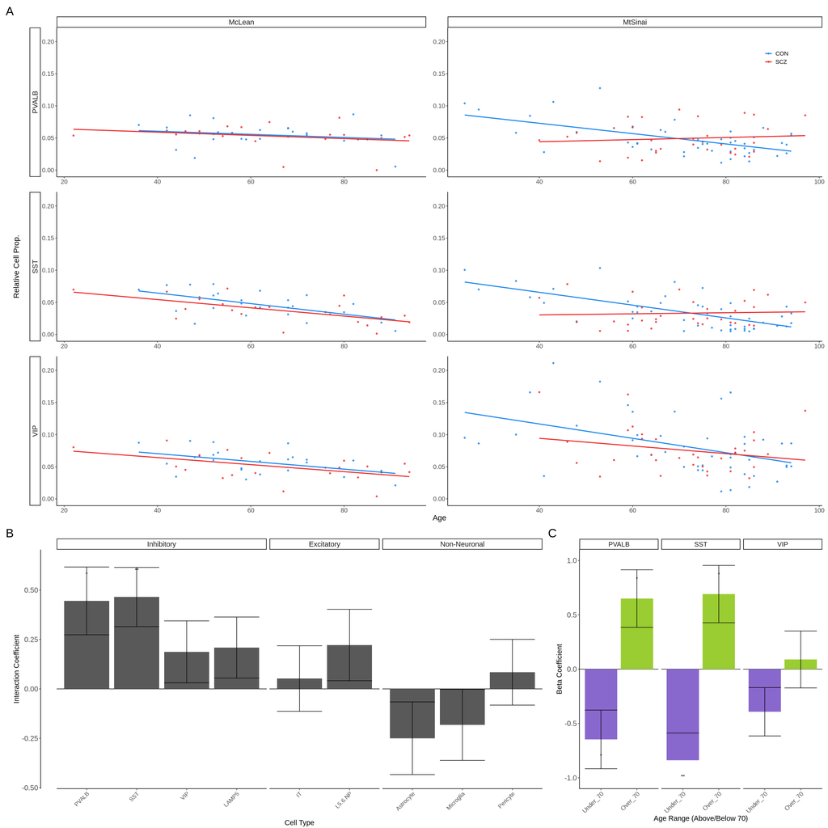

```r
figure_3
```

```r
#Save to plots folder
output_filename <- "~/cell_prop_psychiatry/plots/figure_3.jpg"

# Use ggsave to save the plot as a JPG image
ggsave(output_filename, figure_3, width = 13, height = 14, dpi = 500)
```

Figure 5: AgeOnset vs. MGP

```r
#Duration of Illness
mgp_estimations_long$durationIllness <- mgp_estimations_long$ageDeath - mgp_estimations_long$ageOnset

CELL_TYPES = c("SST", "PVALB", "VIP")
DATASETS = c("GVEX", "LIBD_szControl","CMC")
ageOnset_residuals_data = matrix(ncol = (ncol(mgp_estimations_long)+1), nrow = 0) %>% data.frame()
colnames(ageOnset_residuals_data) = c(colnames(mgp_estimations_long), "resid")

for(DATASET in DATASETS) {
  for(CELL_TYPE in CELL_TYPES) {
    #Create res_model without ageOnset variable
    res_model_data = mgp_estimations_long %>% filter(primaryDiagnosis %in% c('Schizophrenia'), cell_type == CELL_TYPE , dataset == DATASET, is.na(ageOnset) == F)
    #Model without ageOnset
    res_model = lm(scale(rel_prop) ~ scale(ageDeath) + scale(RIN) + scale(PMI) + reportedGender, data = res_model_data)
    #Calculate residuals and add column to res_model_data
    res_model_data = res_model_data %>% add_residuals(var = "resid", model = res_model)
    ageOnset_residuals_data = ageOnset_residuals_data %>% rbind(res_model_data)
  }
}

figure_5 <- ageOnset_residuals_data %>%
  ggplot(aes(x = ageOnset, y = resid, color = dataset)) +
  geom_point(alpha = 0.5, size = 0.5) +
  geom_smooth(se = FALSE, method = 'lm', fullrange = TRUE) +
  ylab('Residualized CTP Estimate') +
  xlab('Age of SCZ Onset') +
  theme(
    axis.text.x = element_text(size = 16),
    axis.text.y = element_text(size = 16),
    axis.title.x = element_text(vjust = -2, size = 16, margin = margin(t = 8)),
    axis.title.y = element_text(size = 16),
    strip.text = element_text(size = 16),
    legend.text = element_text(size = 16),
    plot.margin = margin(10, 10, 20, 10)) +
  facet_grid(cols = vars(cell_type), rows = vars(dataset)) +
  scale_y_continuous(limits = c(-1.5, 1.5)) +
  scale_color_manual(values = c("dodgerblue2", "firebrick2", "green")) +
  guides(color = guide_legend(title = NULL)) +
  stat_cor(aes(label = paste(..r.label.., ..p.label.., sep = "~")), color = "black", geom = "label")


figure_5
```

[output not shown]